# Regression model III : Inference

## Statistical inference

“Statistical inference is the process of using data analysis to deduce properties of an underlying probability distribution.”

Assuming any distributional form of the error is not necessary if you are only interested in point estimation. But, if we want to make any confidence intervals or perform any hypothesis tests using the most commonly used methods, we will need to do this.

The most common approach is that we assume the error is normally distributed. If not? We might deal data in a different way. Anyway, we start from this normal assumption.

$$y=X\beta + \epsilon ,~\epsilon \sim N(0,\sigma^2 I)$$

Note that the assumption also includes independence and equal variance assumptions on the error. The above form can be written as a compact way

$$y\sim N(X\beta, \sigma^2 I)$$

Under this assumption. we can deduce that the distribution of the least squares estimator is also normal as

$$\hat\beta = (X^\top X)^{-1} X^\top y \sim N(\beta, (X^\top X)^{-1} \sigma^2)$$

Q. Are $\hat\beta_j$ and $\hat\beta_k$ are independent or not for $j\neq k$?

## Tests to compare models (Large vs small models)

Given several predictors for a response, we might wonder whether all are needed. Consider a larger model, $\Omega$, and a smaller model, $\omega$, which consists of a subset of the predictors that are in Ω. If there is not much difference in the fit, we would prefer the smaller model on the principle that simpler explanations are preferred.

If $RSS_\omega−RSS_\Omega$ is small, then the fit of the smaller model is almost as good as the larger model and so we would prefer the smaller model on the grounds of simplicity.

This suggests that something like:

$$\frac{RSS_\omega - RSS_\Omega}{RSS_\Omega}$$

would be a potentially good test statistic where the denominator is used for scaling purposes.

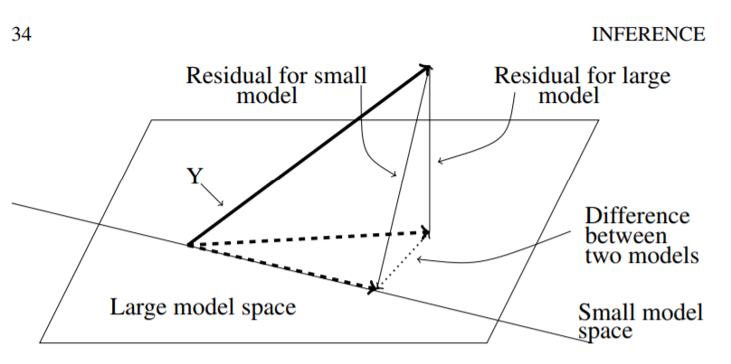

The same test statistic arises from the likelihood-ratio testing approach. If $L(\beta,\sigma|y)$ is the likelihood function, then from the likelihood-ratio statistic we can set a rejection region as:

$$\frac{\underset{\beta,\sigma \in \Omega}{\max}L(\beta,\sigma|y)}{ \underset{\beta,\sigma \in \omega}{\max} L(\beta,\sigma|y)} > c_0$$

After a little algebra, we obtain the from as:

$$\frac{RSS_\omega - RSS_\Omega}{RSS_\Omega} > c$$

for some constant $c$, which is the same statistic suggested by the geometric view. Let the dimensions of $\Omega$ and $\omega$ be $p$ and $q$, respectively.

From distributional properties, we can deduce that

$$\frac{(RSS_\omega - RSS_\Omega)/(p-q)}{RSS_\Omega/(n-p)} \sim F_{p-q,n-p}$$

This test is very widely used in regression and analysis of variance. Detailes are omitted.

Q. Determine the value of $c$ for rejection.

> Note : The degrees of freedom of RSS are (usually) the number of observations minus the number of parameters so this test statistic can also be written:

$$\frac{(RSS_\omega - RSS_\Omega)/(df_\omega-df_\Omega)}{RSS_\Omega/df_\Omega} \sim F_{p-q,n-p}$$

## Testing examples

### Test of all the predictors

Full model ($\Omega$) : $y=X\beta +\epsilon$

Reduced model ($\omega$) : $y=\mu + \epsilon$

In $\Omega$, there are $p+1$ regression parameters and in $\omega$ there is only one parameter and are no predictors. In this case, the hypothesis we want to test can be written as:

$$H_0 : \beta_1=\cdots=\beta_p = 0~~~vs~~~H_1 : \mbox{at least one } \beta_j \mbox{ is not zero}$$

Under the $H_0$, $\omega$ is the true model and $\mu$ can be estimated by $\bar y$.

Now, $RSS_\Omega = \hat\epsilon^\top\hat\epsilon=RSS$ and $RSS_\omega = (y-\bar y)^\top (y-\bar y) = SST$. The $F$-statistc is

$$F=\frac{(SST-RSS)/p}{RSS/(n-p-1)} \sim F_{p.n-p-1}~~\mbox{ under } H_0$$

Q. What is the critical value at the significance level $\alpha$?

Traditionally, the information in the above test is presented in an analysis of variance or ANOVA table. Most computer packages produce a variant on this.

(Note that in the table given below $p$ represents the total number of parameter to be estimated.)

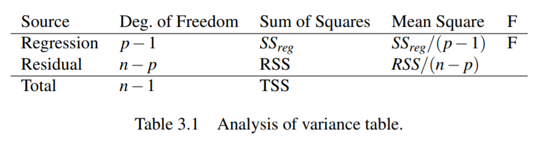

> Example : Galapagos Islands dataset `gala`

```r
library(faraway)
data(gala, package="faraway")
lmod <- lm(Species ~ Area + Elevation + Nearest + Scruz  + Adjacent, gala)  # fitting linear model with 5 predictors
nullmod <- lm(Species ~ 1, gala)   # fitting linear model with 0 predictor (null model)
anova(nullmod, lmod)               # F-test (ANOVA table)
```

```
## Analysis of Variance Table
##
## Model 1: Species ~ 1
## Model 2: Species ~ Area + Elevation + Nearest + Scruz + Adjacent
##   Res.Df    RSS Df Sum of Sq      F    Pr(>F)
## 1     29 381081
## 2     24  89231  5    291850 15.699 6.838e-07 ***
## ---
## Signif. codes:  0 '***' 0.001 '**' 0.01 '*' 0.05 '.' 0.1 ' ' 1
```

We conclude that there is an evidence that some of predictors are relevant at the significance level 0.05. Let us repeat the calucation by hands.

```r
y = gala$Species                    # observed response
haty1 = lmod$fitted.values          # fitted response in full model
haty0 = nullmod$fitted.values       # fitted response in null model
(RSS1 = t(y-haty1)%*%(y-haty1))     # RSS in full model
```

```
##          [,1]
## [1,] 89231.37
```

```r
(RSS0 = t(y-haty0)%*%(y-haty0))     # RSS in null(reduced) model
```

```
##          [,1]
## [1,] 381081.4
```

```r
( Fstat = (((RSS0-RSS1)/(length(lmod$coefficients)-1)) / (RSS1/(length(y)-length(lmod$coefficients))))  ) # F-statistic
```

```
##          [,1]
## [1,] 15.69941
```

```r
1-pf(Fstat,(length(lmod$coefficients)-1),(length(y)-length(lmod$coefficients))) # p-value
```

```
##              [,1]
## [1,] 6.837893e-07
```

The same derivation is possible with `deviance` function in R.

```r
(rss0 <- deviance(nullmod))
```

```
## [1] 381081.4
```

```r
(rss <- deviance(lmod))
```

```
## [1] 89231.37
```

```r
(df0 <- df.residual(nullmod))
```

```
## [1] 29
```

```r
(df <- df.residual(lmod))
```

```
## [1] 24
```

```r
(fstat <- ((rss0-rss)/(df0-df))/(rss/df))
```

```
## [1] 15.69941
```

```r
1-pf(fstat, df0-df, df)
```

```
## [1] 6.837893e-07
```

The same information can be found below.

```r
summary(lmod)
```

```
##
## Call:
## lm(formula = Species ~ Area + Elevation + Nearest + Scruz + Adjacent,
##     data = gala)
##
## Residuals:
##      Min       1Q   Median       3Q      Max
## -111.679  -34.898   -7.862   33.460  182.584
##
## Coefficients:
##              Estimate Std. Error t value Pr(>|t|)
## (Intercept)  7.068221  19.154198   0.369 0.715351
## Area        -0.023938   0.022422  -1.068 0.296318
## Elevation    0.319465   0.053663   5.953 3.82e-06 ***
## Nearest      0.009144   1.054136   0.009 0.993151
## Scruz       -0.240524   0.215402  -1.117 0.275208
## Adjacent    -0.074805   0.017700  -4.226 0.000297 ***
## ---
## Signif. codes:  0 '***' 0.001 '**' 0.01 '*' 0.05 '.' 0.1 ' ' 1
##
## Residual standard error: 60.98 on 24 degrees of freedom
## Multiple R-squared:  0.7658, Adjusted R-squared:  0.7171
## F-statistic:  15.7 on 5 and 24 DF,  p-value: 6.838e-07
```

### Testing one predictor

Can one particular predictor be dropped from the model? The null hypothesis is then

$$H_0 : \beta_j = 0 ~~~vs~~~H_1:\beta_j\neq 0$$

Let $\Omega$ be the model with all the predictors of interest which has $p+1$ parameters and let $\omega$ be the model with all the same predictors except predictor $j$.

> Example : Let’s suppress `Area` in the model.

```r
lmods <- lm(Species ~  Elevation + Nearest + Scruz + Adjacent, gala)  # reduced model
anova(lmods, lmod)
```

```
## Analysis of Variance Table
##
## Model 1: Species ~ Elevation + Nearest + Scruz + Adjacent
## Model 2: Species ~ Area + Elevation + Nearest + Scruz + Adjacent
##   Res.Df   RSS Df Sum of Sq      F Pr(>F)
## 1     25 93469
## 2     24 89231  1    4237.7 1.1398 0.2963
```

An alternative approach is to use a $t$-statistic for testing the hypothesis:

$$t_j = \hat\beta_j / s.e.(\hat\beta_j)$$

This can be done via `summary` fucntion

```r
summary(lmod)
```

```
##
## Call:
## lm(formula = Species ~ Area + Elevation + Nearest + Scruz + Adjacent,
##     data = gala)
##
## Residuals:
##      Min       1Q   Median       3Q      Max
## -111.679  -34.898   -7.862   33.460  182.584
##
## Coefficients:
##              Estimate Std. Error t value Pr(>|t|)
## (Intercept)  7.068221  19.154198   0.369 0.715351
## Area        -0.023938   0.022422  -1.068 0.296318
## Elevation    0.319465   0.053663   5.953 3.82e-06 ***
## Nearest      0.009144   1.054136   0.009 0.993151
## Scruz       -0.240524   0.215402  -1.117 0.275208
## Adjacent    -0.074805   0.017700  -4.226 0.000297 ***
## ---
## Signif. codes:  0 '***' 0.001 '**' 0.01 '*' 0.05 '.' 0.1 ' ' 1
##
## Residual standard error: 60.98 on 24 degrees of freedom
## Multiple R-squared:  0.7658, Adjusted R-squared:  0.7171
## F-statistic:  15.7 on 5 and 24 DF,  p-value: 6.838e-07
```

That is, a single predictor can be tested via $t$-statistic as well as $F$-statistic. Two results are the same.

Note that it is very important that we specify which other predictors are included in the models specifying the null and alternative. For example,

```r
sumary(lm(Species ~ Area, gala))
```

```
##              Estimate Std. Error t value  Pr(>|t|)
## (Intercept) 63.782861  17.524416  3.6397 0.0010943
## Area         0.081963   0.019713  4.1578 0.0002748
##
## n = 30, p = 2, Residual SE = 91.73159, R-Squared = 0.38
```

The result is quite different from the case that there are other predictors in the model.

### Testing a pair of predictors

Suppose we were interested in whether the area of either the current island or the adjacent island had any relation to the response.

> Example : Let’s suppress `Area` and `Adjacent` in the model.

```r
lmods <- lm(Species ~  Elevation + Nearest + Scruz, gala)
anova(lmods, lmod)
```

```
## Analysis of Variance Table
##
## Model 1: Species ~ Elevation + Nearest + Scruz
## Model 2: Species ~ Area + Elevation + Nearest + Scruz + Adjacent
##   Res.Df    RSS Df Sum of Sq      F  Pr(>F)
## 1     26 158292
## 2     24  89231  2     69060 9.2874 0.00103 **
## ---
## Signif. codes:  0 '***' 0.001 '**' 0.01 '*' 0.05 '.' 0.1 ' ' 1
```

Now you may wonder whether we could have divined the same result from looking at the regression summary output where the corresponding $p$-values for the two terms are 0.3 and 0.0003. Immediately, we have the problem of making a decision based on two $p$-values rather than one. There is no simple way to combine these. In short, if you want to test two (or more) predictors, you need to use the single $F$-test.

### Testing a subspace

Consider an example where we test whether the areas of the current and adjacent island can be added together and used in place of the two separate predictors. Such a test can be expressed as the hypothesis that:

$$\beta_{Area} = \beta_{Adjacent}$$

```r
lmods <- lm(Species ~  I(Area+Adjacent) + Elevation + Nearest + Scruz, gala)
anova(lmods, lmod)
```

```
## Analysis of Variance Table
##
## Model 1: Species ~ I(Area + Adjacent) + Elevation + Nearest + Scruz
## Model 2: Species ~ Area + Elevation + Nearest + Scruz + Adjacent
##   Res.Df    RSS Df Sum of Sq     F  Pr(>F)
## 1     25 109591
## 2     24  89231  1     20360 5.476 0.02793 *
## ---
## Signif. codes:  0 '***' 0.001 '**' 0.01 '*' 0.05 '.' 0.1 ' ' 1
```

The function `I()` ensures that the argument is evaluated (in this case actual addition) rather than interpreted as part of the model formula.

Another example of subspace testing occurs when we want to test whether a parameter can be set to a particular value. For example:

$$\beta_{Elevation} = 0.5$$

This specifies a particular subspace of the full model. We can set a fixed term in the regression equation using an offset.

```r
lmods <- lm(Species ~  Area+ offset(0.5*Elevation) + Nearest + Scruz + Adjacent, gala)
anova(lmods, lmod)
```

```
## Analysis of Variance Table
##
## Model 1: Species ~ Area + offset(0.5 * Elevation) + Nearest + Scruz +
##     Adjacent
## Model 2: Species ~ Area + Elevation + Nearest + Scruz + Adjacent
##   Res.Df    RSS Df Sum of Sq      F   Pr(>F)
## 1     25 131312
## 2     24  89231  1     42081 11.318 0.002574 **
## ---
## Signif. codes:  0 '***' 0.001 '**' 0.01 '*' 0.05 '.' 0.1 ' ' 1
```

A simpler way to test such point hypotheses is to use a $t$-statistic:

$$t_j = (\hat\beta_j - c )/ s.e.(\hat\beta_j)$$

where $c$ is the point hypothesis.

```r
(tstat <- (0.31946-0.5)/0.05366)
```

```
## [1] -3.364517
```

```r
2*pt(tstat, 24)
```

```
## [1] 0.002572168
```

## Confidence interval for $\beta$

Confidence intervals (CIs) provide an alternative way of expressing the uncertainty in the estimates of $\beta$. They take the form:

$$\hat\beta_j \pm t_{\alpha/2}(n-p-1)s.e.(\hat\beta_j)$$

```r
lmod <- lm(Species ~ Area + Elevation + Nearest + Scruz  + Adjacent, gala)
sumary(lmod)
```

```
##              Estimate Std. Error t value  Pr(>|t|)
## (Intercept)  7.068221  19.154198  0.3690 0.7153508
## Area        -0.023938   0.022422 -1.0676 0.2963180
## Elevation    0.319465   0.053663  5.9532 3.823e-06
## Nearest      0.009144   1.054136  0.0087 0.9931506
## Scruz       -0.240524   0.215402 -1.1166 0.2752082
## Adjacent    -0.074805   0.017700 -4.2262 0.0002971
##
## n = 30, p = 6, Residual SE = 60.97519, R-Squared = 0.77
```

```r
qt(0.975, 30-6)
```

```
## [1] 2.063899
```

```r
-0.02394 + c(-1,1) *  2.0639 * 0.02242  # C.I. for beta_Area
```

```
## [1] -0.07021264  0.02233264
```

```r
-0.07480 + c(-1,1) *  2.0639 * 0.01770  # C.I. for beta_Adjacent
```

```
## [1] -0.11133103 -0.03826897
```

Q. Do the intervals cross zero? What can we deduce from that?

```r
confint(lmod)   # easy way to get intervals
```

```
##                   2.5 %      97.5 %
## (Intercept) -32.4641006 46.60054205
## Area         -0.0702158  0.02233912
## Elevation     0.2087102  0.43021935
## Nearest      -2.1664857  2.18477363
## Scruz        -0.6850926  0.20404416
## Adjacent     -0.1113362 -0.03827344
```

The advantage of the confidence interval relative to the corresponding hypothesis test is that we get information about plausible ranges for the parameters. This is particularly valuable when the parameter is directly interpretable (for example, as the difference between two treatments).

If you are interested in more than one parameter, you can construct a $100(1−\alpha)\%$ confidence region for $\beta$ using:

$$(\hat\beta - \beta)^\top X^\top X(\hat\beta - \beta) \sim (p+1) \hat\sigma^2 F_{p+1,n-p-1}$$

These regions are ellipsoidally shaped. Because these ellipsoids lie in higher dimensions, they cannot easily be visualized except for the two-dimensional case.

> Example : joint 95% confidence region for $\beta_{Area}$ and $\beta_{Adjacent}$.

```r
library(ellipse)
```

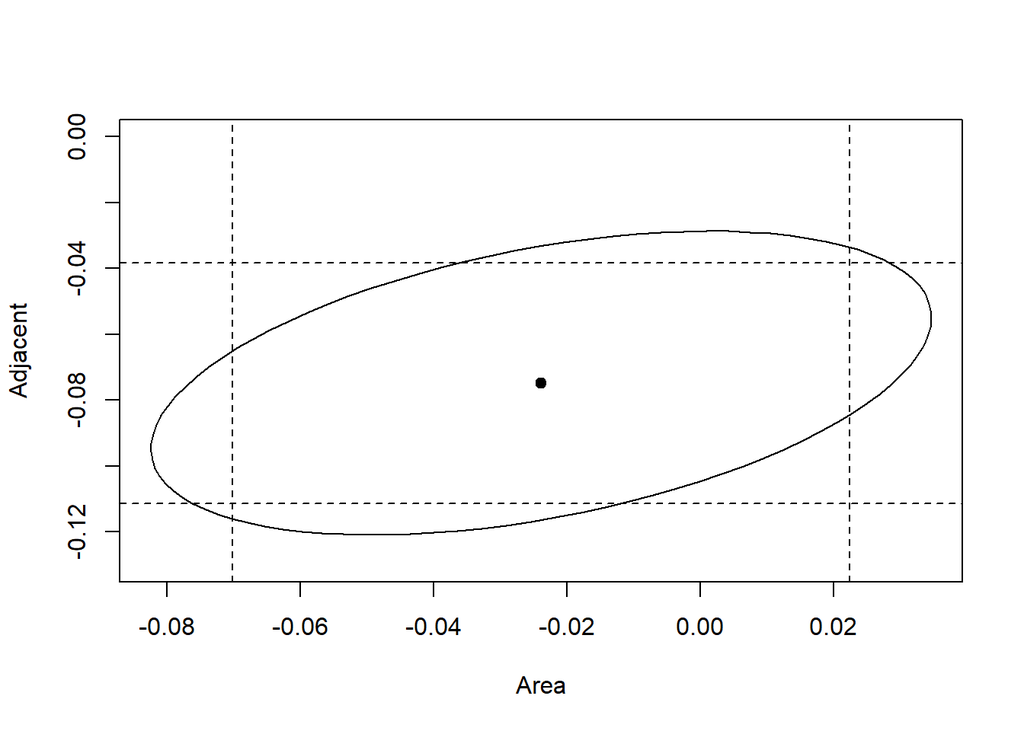

```r
plot(ellipse(lmod,c(2,6)),type="l",ylim=c(-0.13,0))
points(coef(lmod)[2], coef(lmod)[6], pch=19)
abline(v=confint(lmod)[2,],lty=2)
abline(h=confint(lmod)[6,],lty=2)
```

Q. What can you decide from this plot?

## Exercise

# 7 (a)$\sim$(f) in page in Chapter 3 (page 50 in the second edition)